# EFAshiny : R Code Demo

### Overview

This tutorial aims to demonstrate how to perform the fundamental analyses in [`EFAshiny`](https://psychilin.shinyapps.io/EFAshiny/) using R code. By following each line in this tutorial, you can learn basic R programming and can implement automated processing script in future analyses. Also, you can further use the code in `EFAshiny` within a script pupeline without launching the app. However, we still suggest you to use [`EFAshiny`](https://psychilin.shinyapps.io/EFAshiny/) APP :)) You can also have a look at our [tutorial](https://github.com/PsyChiLin/EFAshiny) of `EFAshiny` GUI to make an easy comparison while writing the code. Have fun with [`EFAshiny`](https://psychilin.shinyapps.io/EFAshiny/) and `R` !

### Preparation

First of all, we should load all the packages and fucntions in `EFAshiny` into `R` session. If you do not have these package installed, please use `install.package("packagename")` to perfrom installations.

```r
require(ggplot2);require(psych);require(corrplot);require(reshape2);require(moments);require(gridExtra)
require(qgraph);require(bootnet);require(igraph);require(ggcorrplot);require(RCurl)
source("https://raw.githubusercontent.com/PsyChiLin/EFAshiny/master/inst/efas/functions/my_summary.R")
source("https://raw.githubusercontent.com/PsyChiLin/EFAshiny/master/inst/efas/functions/faplot.R")
source("https://raw.githubusercontent.com/PsyChiLin/EFAshiny/master/inst/efas/functions/bootEGA.R")
source("https://raw.githubusercontent.com/PsyChiLin/EFAshiny/master/inst/efas/functions/bargraph.R")
source("https://raw.githubusercontent.com/PsyChiLin/EFAshiny/master/inst/efas/functions/stackbar.R")
source("https://raw.githubusercontent.com/PsyChiLin/EFAshiny/master/inst/efas/functions/printLoadings.R")
source("https://raw.githubusercontent.com/PsyChiLin/EFAshiny/master/inst/efas/functions/theme_default.R")
```

### Data Input

Read the demonsration data [`RSE`](https://github.com/PsyChiLin/EFAshiny/blob/master/RSE/RSE.csv) into `R`. We assign it to a object called `dta`. Then using `head` to observe and explore this data. See our [tutorial](https://github.com/PsyChiLin/EFAshiny) for data description.

```r
dta <- read.csv(text=getURL("https://raw.githubusercontent.com/PsyChiLin/EFAshiny/master/RSE/RSE.csv"))
head(dta)
```

```
##   Q1 Q2 Q3 Q4 Q5 Q6 Q7 Q8 Q9 Q10
## 1  4  4  1  4  1  3  3  2  1   1
## 2  1  2  3  2  2  2  1  3  4   4
## 3  3  3  2  3  1  2  3  4  4   4
## 4  3  3  3  4  2  2  1  4  4   4
## 5  2  2  3  2  2  1  2  4  4   4
## 6  3  3  3  2  3  2  2  3  3   2
```

### Data Summary

Several kinds of data summary can be perform in `EFAshiny`. We demonstrate them using basic code. The package `ggplot2` is a useful package for plotting. We use it to plot the histograms, the density plots, and the correlation matrix. You can also check the documentation of [`ggplot2`](https://cran.r-project.org/web/packages/ggplot2/ggplot2.pdf).

##### Numeric Statistic

```r
NumericStatistic <- apply(dta,2,my_summary)
row.names(NumericStatistic) <- c("Mean","SD","Skewness","Kurtosis","Median","MAD")
NumericStatistic <- as.data.frame(t(NumericStatistic))
NumericStatistic <- round(NumericStatistic,3)
NumericStatistic
```

```
##      Mean    SD Skewness Kurtosis Median   MAD
## Q1  2.930 0.878   -0.489    2.543      3 1.483
## Q2  3.027 0.794   -0.661    3.222      3 0.000
## Q3  2.387 0.943    0.118    2.116      2 1.483
## Q4  2.926 0.796   -0.474    2.898      3 0.000
## Q5  2.441 0.968    0.036    2.028      2 1.483
## Q6  2.398 0.889    0.073    2.266      2 1.483
## Q7  2.285 0.908    0.101    2.137      2 1.483
## Q8  2.754 0.945   -0.332    2.222      3 1.483
## Q9  2.848 0.964   -0.534    2.367      3 1.483
## Q10 2.695 1.056   -0.270    1.866      3 1.483
```

##### Histogram

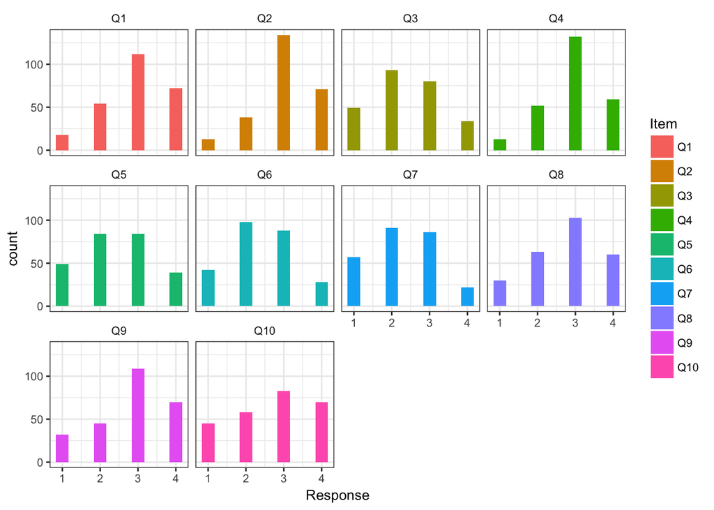

```r
dta_long <- melt(dta)
colnames(dta_long) <- c("Item", "Response")
Histogram <- ggplot(dta_long, aes(x = Response, fill = Item))+
        geom_histogram(bins = 10)+
        facet_wrap(~Item)+
        theme_default()
Histogram
```

##### Density Plot

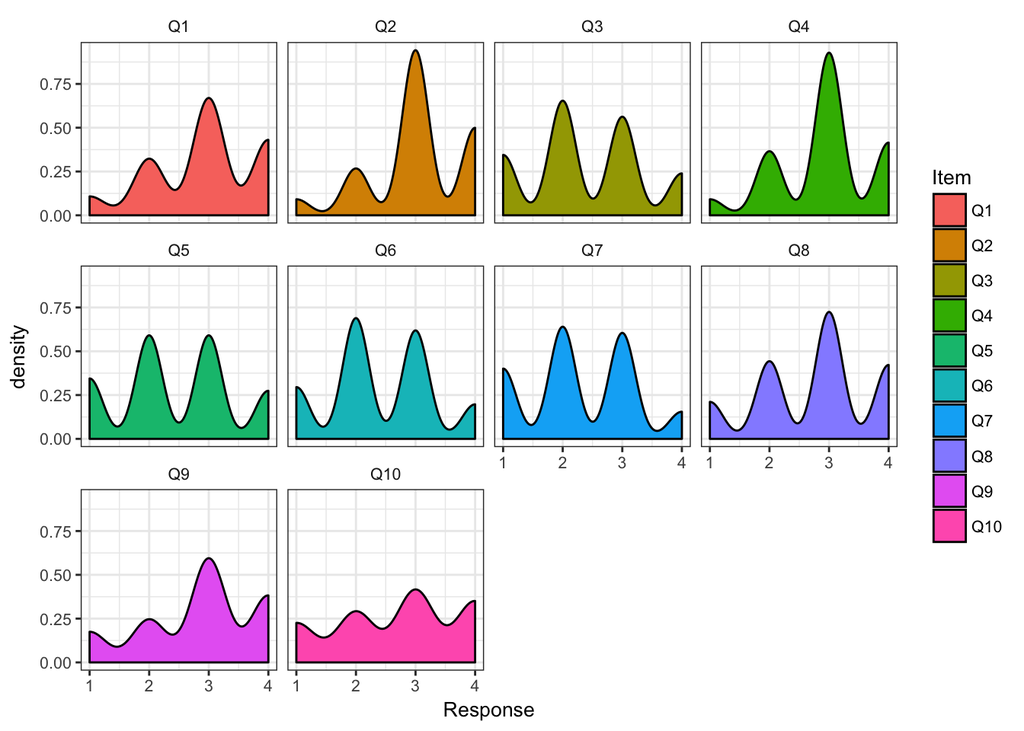

```r
DensityPlot <- ggplot(dta_long, aes(x = Response, fill = Item))+
        geom_density()+
        facet_wrap(~Item)+
        theme_default()
DensityPlot
```

##### Correlation Matrix

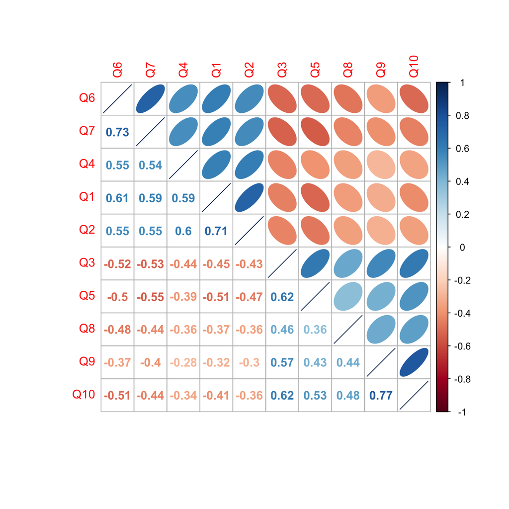

```r
CorMat <- cor(as.matrix(dta))
corrplot(CorMat,order="hclust",type="upper",method="ellipse",
         tl.pos = "lt",mar = c(2,2,2,2))
corrplot(CorMat,order="hclust",type="lower",method="number",
         diag=FALSE,tl.pos="n", cl.pos="n",add=TRUE,mar = c(2,2,2,2))
```

##### ggcorplot

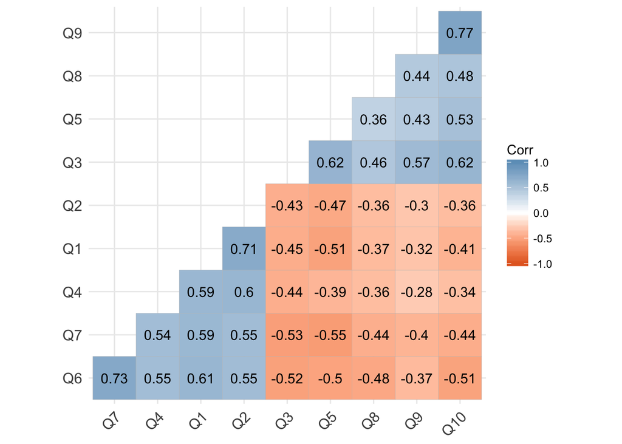

```r
ggcorrplot(CorMat, hc.order = T,type = "lower", lab = TRUE,
           colors = c("#E46726", "white", "#6D9EC2"))
```

### Factor Retention

We provide several factor retention methods in `EFAshiny`. Those analyses can also be performed using R code. You can adopt these methods for your own use.

##### Scree Plot and Parallel Analysis

```r
PA <- faplot(CorMat,n.obs = 256, quant = 0.95)
```

```
## Parallel analysis suggests that the number of factors =  NA  and the number of components =  2
```

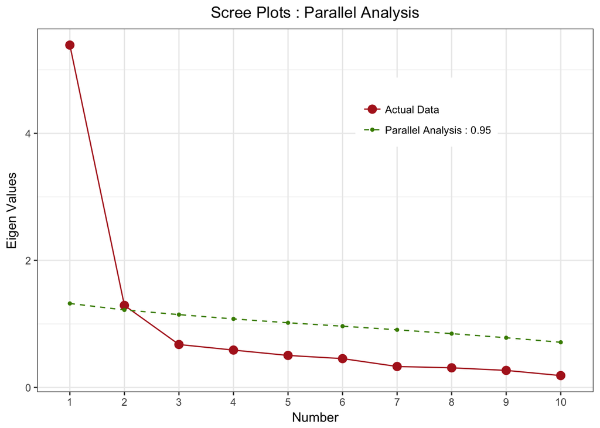

```r
PA[[1]]
```

##### Numeric Rules

```r
NumericRule <- VSS(CorMat,n = 4, plot = F, n.obs = 256)
temp1 <- data.frame(nFactor = row.names(NumericRule$vss.stats),
                     VSS1 = NumericRule$cfit.1, VSS2 = NumericRule$cfit.2,
                     MAP = NumericRule$map)
temp2 <- NumericRule$vss.stats[,c(6:8,11)]
NumericRule <- cbind(temp1,temp2)
NumericRule
```

```
##   nFactor      VSS1      VSS2        MAP      RMSEA       BIC      SABIC
## 1       1 0.8914042 0.0000000 0.05447774 0.18020765 124.59929 235.558803
## 2       2 0.6280592 0.9415872 0.04162043 0.10067140 -52.99140  29.435667
## 3       3 0.4763088 0.7915412 0.07233850 0.07679094 -55.83651   1.228384
## 4       4 0.4340840 0.7117347 0.09725540 0.03740394 -46.47254 -11.599548
##         SRMR
## 1 0.09574323
## 2 0.03536388
## 3 0.02436892
## 4 0.01113139
```

##### Exploratory Graph Analysis (EGA)

```r
EGArst <- bootEGA(data = dta, n = 10, medianStructure = TRUE, plot.MedianStructure = TRUE,
                  ncores = 4, layout = "spring")
```

```
## model set to 'GGM'
```

```
## Estimating sample network...
```

```
## Estimating Network. Using package::function:
##   - qgraph::EBICglasso for EBIC model selection
##     - using glasso::glasso
##   - qgraph::cor_auto for correlation computation
##     - using lavaan::lavCor
```

```
## Variables detected as ordinal: Q1; Q2; Q3; Q4; Q5; Q6; Q7; Q8; Q9; Q10
```

```
## Bootstrapping...
```

```
## Computing statistics...
```

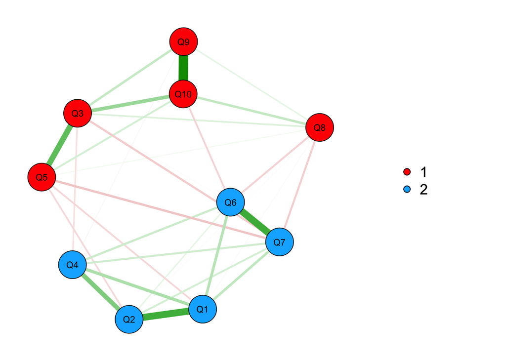

```r
plot(EGArst$plot)
```

### Extarction and Rotation

The key analyses in EFA is factor extarction and rotation. We teach you to perform the analyses using `psych` package. Using these lines, you can obtain basic results of EFA. Can also see the code in `EFAshiny` server and `psych` package for details.

```r
EFArst <- fa(CorMat,2,n.obs=256, rotate = "promax",fm = "pa", n.iter = 200)
EFArst
```

```
## Factor Analysis with confidence intervals using method = fa(r = CorMat, nfactors = 2, n.obs = 256, n.iter = 200, rotate = "promax",
##     fm = "pa")
## Factor Analysis using method =  pa
## Call: fa(r = CorMat, nfactors = 2, n.obs = 256, n.iter = 200, rotate = "promax",
##     fm = "pa")
## Standardized loadings (pattern matrix) based upon correlation matrix
##       PA1   PA2   h2   u2 com
## Q1   0.88  0.09 0.67 0.33 1.0
## Q2   0.87  0.12 0.62 0.38 1.0
## Q3  -0.23  0.59 0.58 0.42 1.3
## Q4   0.77  0.08 0.52 0.48 1.0
## Q5  -0.39  0.37 0.48 0.52 2.0
## Q6   0.69 -0.14 0.63 0.37 1.1
## Q7   0.70 -0.13 0.62 0.38 1.1
## Q8  -0.23  0.41 0.35 0.65 1.6
## Q9   0.20  0.95 0.68 0.32 1.1
## Q10  0.11  0.96 0.79 0.21 1.0
##
##                        PA1  PA2
## SS loadings           3.40 2.55
## Proportion Var        0.34 0.25
## Cumulative Var        0.34 0.60
## Proportion Explained  0.57 0.43
## Cumulative Proportion 0.57 1.00
##
##  With factor correlations of
##       PA1   PA2
## PA1  1.00 -0.67
## PA2 -0.67  1.00
##
## Mean item complexity =  1.2
## Test of the hypothesis that 2 factors are sufficient.
##
## The degrees of freedom for the null model are  45  and the objective function was  5.73 with Chi Square of  1436.37
## The degrees of freedom for the model are 26  and the objective function was  0.37
##
## The root mean square of the residuals (RMSR) is  0.04
## The df corrected root mean square of the residuals is  0.05
##
## The harmonic number of observations is  256 with the empirical chi square  28.82  with prob <  0.32
```

[output cut: 13 more lines]

```
##       low   PA1 upper   low   PA2 upper
## Q1   0.78  0.88  0.96 -0.04  0.09  0.20
## Q2   0.77  0.87  0.95  0.00  0.12  0.24
## Q3  -0.38 -0.23 -0.11  0.43  0.59  0.74
## Q4   0.66  0.77  0.87 -0.06  0.08  0.20
## Q5  -0.55 -0.39 -0.24  0.22  0.37  0.52
## Q6   0.56  0.69  0.83 -0.28 -0.14 -0.01
## Q7   0.56  0.70  0.83 -0.26 -0.13  0.00
## Q8  -0.37 -0.23 -0.10  0.27  0.41  0.55
## Q9   0.09  0.20  0.30  0.85  0.95  1.02
## Q10  0.01  0.11  0.20  0.88  0.96  1.04
##
##  Interfactor correlations and bootstrapped confidence intervals
##         lower estimate upper
## PA1-PA2 -0.72    -0.67  -0.6
```

### Visualization

By passing the results of EFA from aforementioned analyses into the well-established functions, you can easily visualize these results from EFA. Definitely, `EFAshiny` can help you to do these automatically.

##### Diagram

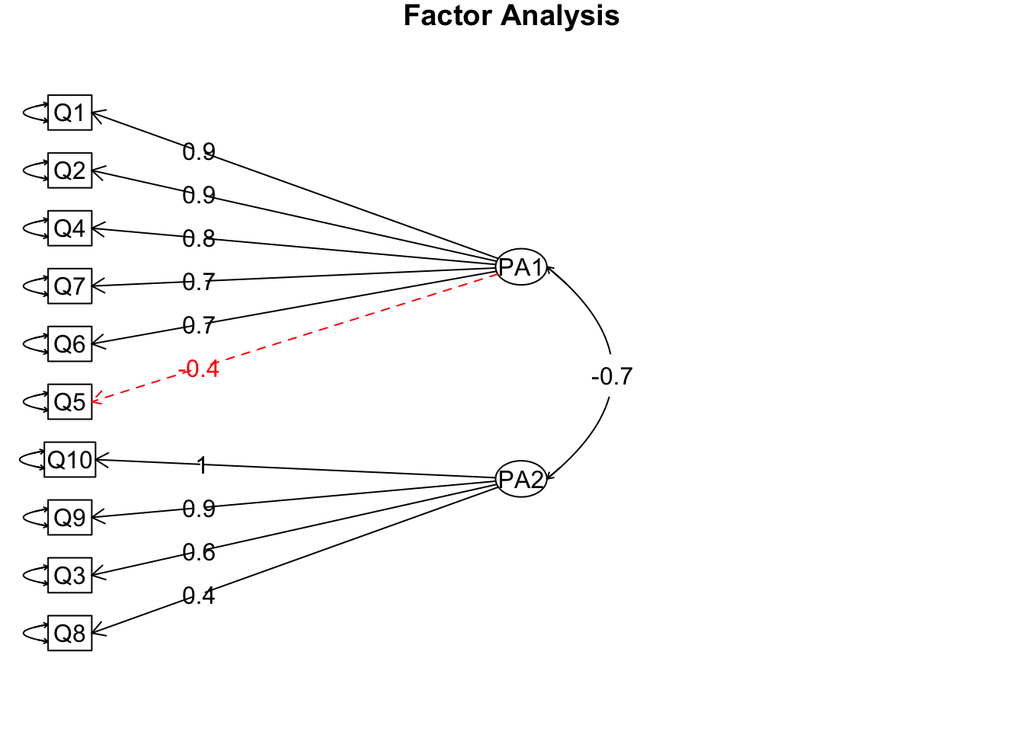

```r
fa.diagram(EFArst,simple = T,cut = 0.33,
           sort = T,errors = T,e.size = 0.05)
```

##### Bootstrapping Factor Loadings

```r
order <- rev(row.names(as.data.frame(printLoadings(EFArst$cis$means,sort = T,cutoff = 0)))) # define the order of the variable
```

```
##
## Loadings:
##     PA1   PA2
## Q1   0.87  0.08
## Q2   0.86  0.12
## Q4   0.77  0.07
## Q7   0.70 -0.13
## Q6   0.69 -0.14
## Q5  -0.39  0.37
## Q10  0.11  0.96
## Q9   0.19  0.94
## Q3  -0.25  0.58
## Q8  -0.24  0.41
```

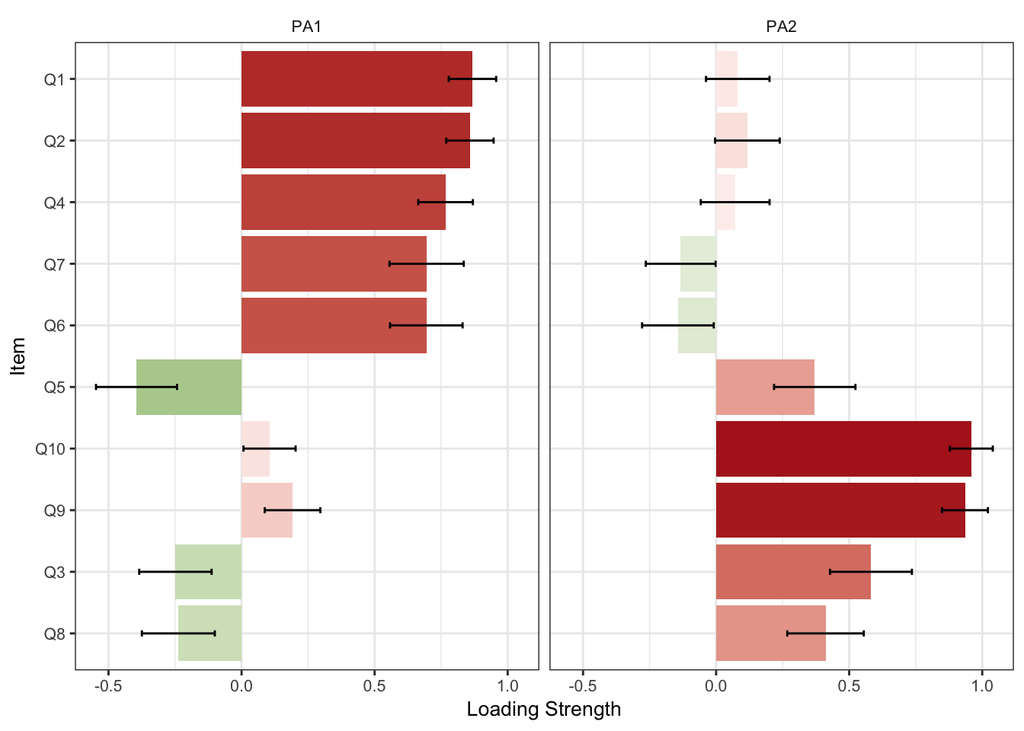

```r
bargraph(EFArst,order = order,nf = 2,highcol = "firebrick",lowcol = "chartreuse4",ci = T)
```

##### Factor Loadings and Correlation Matrix

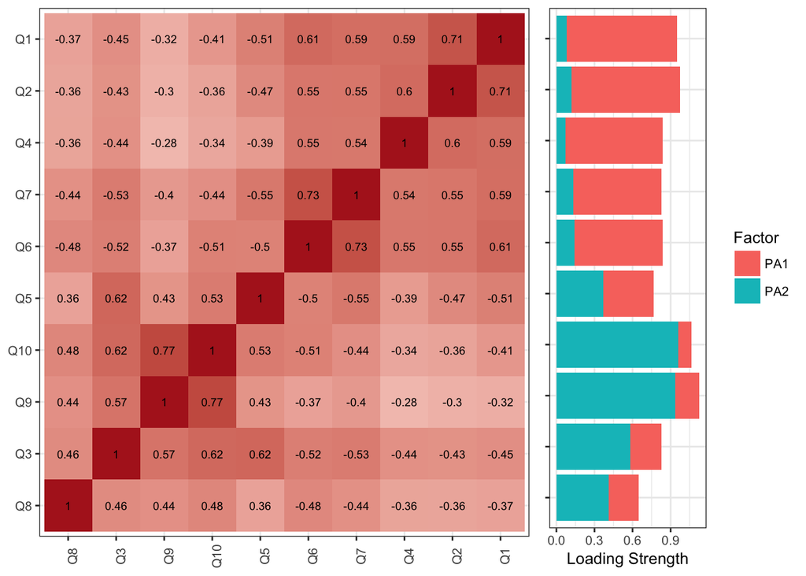

```r
stackbar(CorMat,EFArst,order = order,highcol = "firebrick",lowcol = "chartreuse4")
```